# Projekt Option Price

Jasmin Thevathas

09.06.2018

### Einleitung

In diesem Dokument geht es um die Monte Carlo Simulation von Aktienpreisen. Für die Simulation werden folgende Aktienkurse verwendet: Holidayceck Group, Verianos Real Estate AG, Valero Energy

Diese Daten werden von der Plattform Boerse Stuttgart zur Verfügung gestellt. [https://www.quandl.com/data/SSE-Boerse-Stuttgart]

### Verwendete Libraries

```r
library("Quandl")
library("fOptions")
```

Quandle: Die historischen Basiswerte werden über die Quandle API heruntergeladen fOptions: fOptions beinhaltet Funktionen für die Berechnung der Optionspreise.

### Globale Variablen

```r
#Timespan for data collection
startDate = '2017-06-01'
endDate = '2018-06-01'

#Simulation
#Count of possible price development
nSim = 1000
#Timespan for price development forecasting
nDays = 180
```

### HOLIDAYCHECK GROUP STOCK

https://www.quandl.com/data/SSE/HOC-HOLIDAYCHECK-GROUP-STOCK-WKN-549532-ISIN-DE0005495329-HOC-Stuttgart

#### Historische Werte

Tagesabschlüsse von einem Jahr (01.06.2017 - 01.06.2018) werden heruntergeladen und grafisch dargestellt.

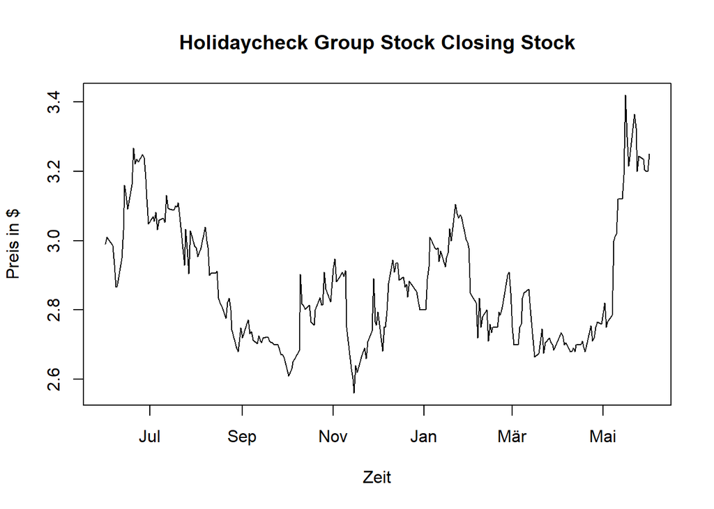

```r
hocDataCode = 'SSE/HOC'
hocLast = Quandl(hocDataCode, type='zoo', collapse="daily", start_date=startDate, end_date=endDate)[,"Last"]

plot(hocLast, ylab="Preis in $",xlab="Zeit",main="Holidaycheck Group Stock Closing Stock")
```

#### Erwartete Tagesrendite [Prozent]

Die prozentuale Tagesrendite ist in der folgenden Graphik zu sehen.

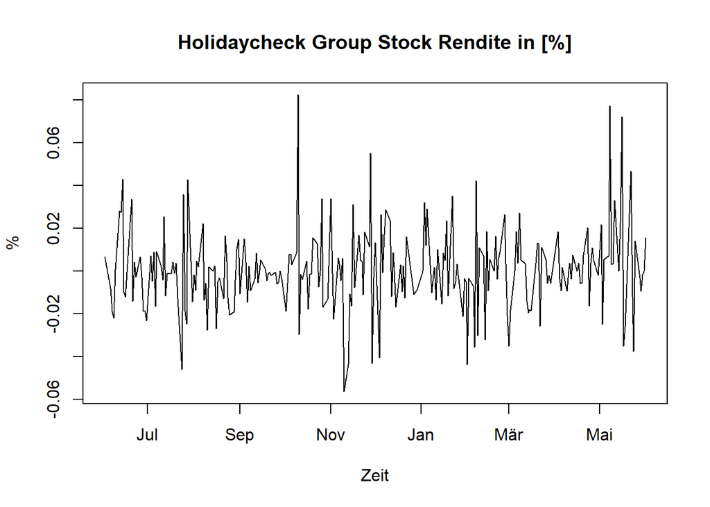

```r
hocReturn = Quandl(hocDataCode, type="zoo",collapse="daily",start_date=startDate, end_date=endDate, transform = "rdiff")[,"Last"]

plot(hocReturn, ylab="%",xlab="Zeit",main="Holidaycheck Group Stock Rendite in [%]")
```

#### Mittelwert und die Standardabweichung

```r
hocSd <- sd(hocReturn)
hocMean <- mean(hocReturn)

hocMatrix = matrix(c(hocSd,hocMean),ncol=2,byrow=TRUE)
colnames(hocMatrix) = c("Standardabweichung","Mittelwert")
print.table(hocMatrix)
```

```
##      Standardabweichung  Mittelwert
## [1,]        0.019186853 0.000514036
```

#### Preisentwicklung mit GBM

Die folgende Graphik zeigt die Simulation mit Geometrischer Brownscher Bewegung. Dargestellt sind 1000 mögliche Preisentwicklungen in dem nächsten halben Jahr.

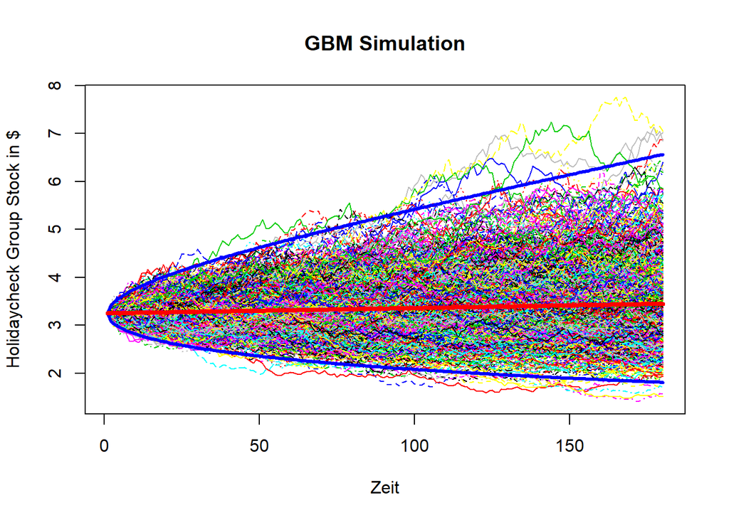

```r
#Simulation
S0 = hocLast[length(hocLast)]
S = matrix(0,nrow=nDays,ncol=nSim)

for (i in 1:nSim) {
  SVec = rep(0, nDays)
  SVec[1] = S0
  for(j in 2:nDays) {
    pastDay = SVec[j-1]
    DeltaS = hocMean*pastDay + hocSd*pastDay*rnorm(1)
    SVec[j] = pastDay+DeltaS
  }
  S[,i] = SVec
}

#Borderlines for the simulation
mean = hocMean * nDays
hocSigma = hocSd * sqrt(nDays)
t = seq(from=0,to=1,length.out=nDays)
meanBnd = vector(length = nDays)
upBnd = vector(length = nDays)
lowBnd = vector(length = nDays)

for(i in 0:nDays){
  meanBnd[i] = S0*exp((( mean-hocSigma^2/2 ))*t[i])
  upBnd[i] = S0*exp((( mean-hocSigma^2/2 ))*t[i] + (hocSigma * 2.5 * sqrt(t[i])))
  lowBnd[i] = S0*exp((( mean-hocSigma^2/2 ))*t[i] + (hocSigma * -2.5 * sqrt(t[i])))
}

#Presentation of the simulation
#Red line: Mean of all simulations
#Blue lines: BOundaris in this simulation
matplot(S,type='l',col=1:100,ylab='Holidaycheck Group Stock in $',xlab='Zeit',main='GBM Simulation')
matlines(lowBnd,lwd=3,col="blue")
matlines(upBnd,lwd=3,col="blue")
matlines(meanBnd,lwd=4,col="red")
```

Die Dichte der Schlusspreise ist in der folgenden Graphik dargestellt.

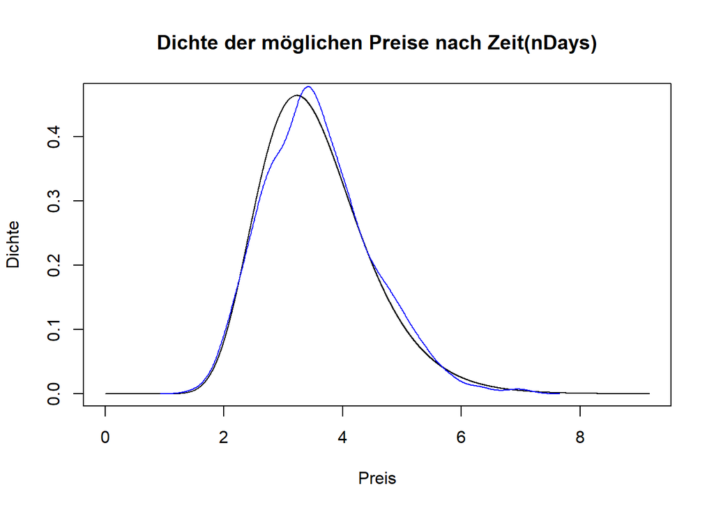

```r
#theoretical density
lnMean = coredata(S0)*exp(hocMean*nDays)
lnSD = coredata(S0)*exp(hocMean*nDays)*sqrt(exp((hocSd^2)*nDays)-1)

meanOfLog = log(S0) + (hocMean-(hocSd^2)/2)*nDays
sdOfLog = hocSd*sqrt(nDays)
priceGrid = seq(0,lnMean+6*lnSD,length=10000)
theoDens = dlnorm(priceGrid,meanOfLog,sdOfLog)
#empirical density
empDens = density(S[nDays,])

#Black line: longnormal distribution of theoretical density
#Blue line: longnormal distribution of empirical density
plot(priceGrid,theoDens,type='l',xlab='Preis',ylab='Dichte',main="Dichte der möglichen Preise nach Zeit(nDays)")
lines(empDens,col='blue')
```

#### Call Put Option price Black Scholes

Resultierende Optionspreise mit dem Modell

```r
S = head(Quandl(hocDataCode, start_date=startDate, end_date=endDate), n=1)$"Previous Day Price"
strikecall = 4
optionCall = GBSOption(TypeFlag = "c", S, strikecall, 1/12, r = 0.03, b = 0.03, hocSigma)
cat("Option Call Price",optionCall@price)
```

```
## Option Call Price 0.0001129561
```

```r
strikeput = 1
optionPut = GBSOption(TypeFlag = "p", S, strikeput, 1/12, r = 0.03, b = 0.03, hocSigma)
cat("Option Put Price",optionPut@price)
```

```
## Option Put Price 0
```

### VERIANOS REAL ESTATE AG STOCK

https://www.quandl.com/data/SSE/VROS-VERIANOS-REAL-ESTATE-AG-STOCK-WKN-A0Z2Y4-ISIN-DE000A0Z2Y48-VROS-Stuttgart

#### Historische Werte

Tagesabschlüsse von einem Jahr (01.06.2017 - 01.06.2018) werden heruntergeladen und grafisch dargestellt.

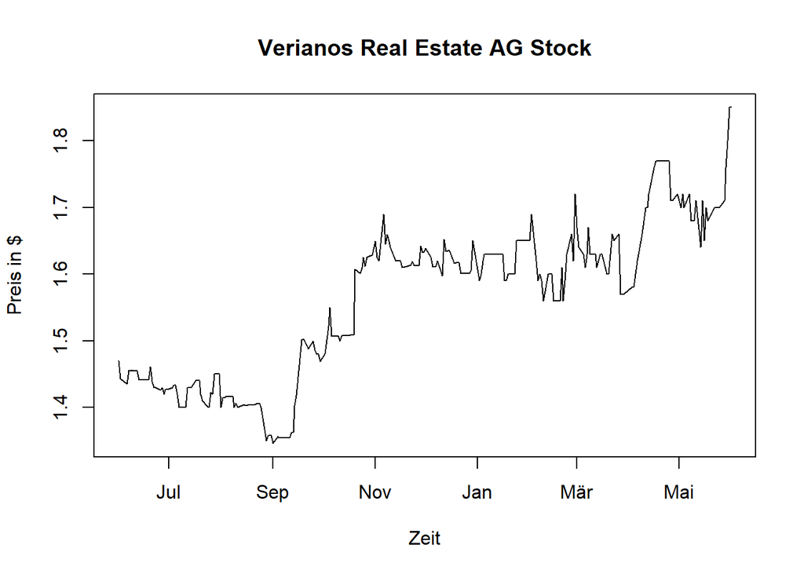

```r
vrosDataCode = 'SSE/VROS'
vrosLast = Quandl(vrosDataCode, type='zoo', collapse="daily", start_date=startDate, end_date=endDate)[,"Last"]

plot(vrosLast, ylab="Preis in $",xlab="Zeit",main="Verianos Real Estate AG Stock")
```

#### Erwartete Tagesrendite [Prozent]

Die prozentuale Tagesrendite ist in der folgenden Graphik zu sehen.

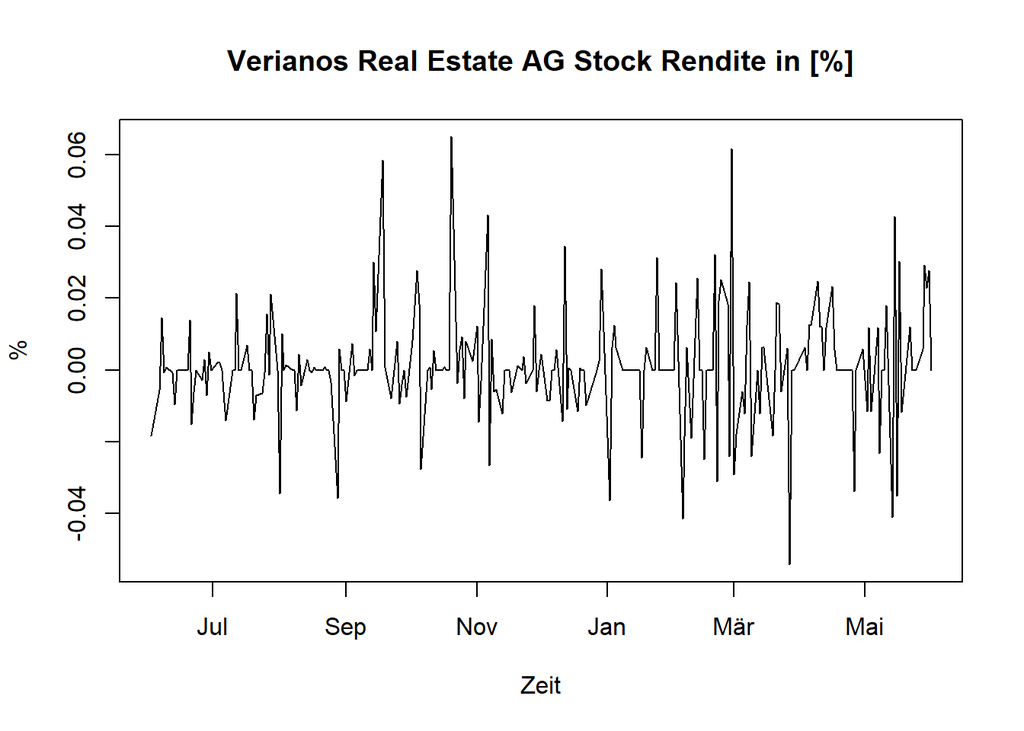

```r
vrosReturn = Quandl(vrosDataCode, type="zoo",collapse="daily",start_date=startDate, end_date=endDate, transform = "rdiff")[,"Last"]

plot(vrosReturn, ylab="%",xlab="Zeit",main="Verianos Real Estate AG Stock Rendite in [%]")
```

#### Mittelwert und die Standardabweichung

```r
vrosSd <- sd(vrosReturn)
vrosMean <- mean(vrosReturn)

vrosMatrix = matrix(c(vrosSd,vrosMean),ncol=2,byrow=TRUE)
colnames(vrosMatrix) = c("Standardabweichung","Mittelwert")
print.table(vrosMatrix)
```

```
##      Standardabweichung Mittelwert
## [1,]         0.01528580 0.00103592
```

#### Preisentwicklung mit GBM

Die folgende Graphik zeigt die Simulation mit Geometrischer Brownscher Bewegung. Dargestellt sind 1000 mögliche Preisentwicklungen in dem nächsten halben Jahr.

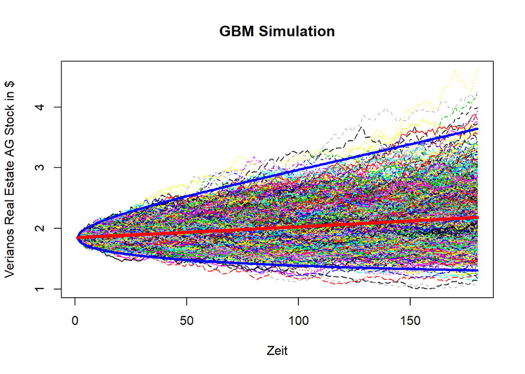

```r
#Simulation
S0 = vrosLast[length(vrosLast)]
S = matrix(0,nrow=nDays,ncol=nSim)

for (i in 1:nSim) {
  SVec = rep(0, nDays)
  SVec[1] = S0
  for(j in 2:nDays) {
    pastDay = SVec[j-1]
    DeltaS = vrosMean*pastDay + vrosSd*pastDay*rnorm(1)
    SVec[j] = pastDay+DeltaS
  }
  S[,i] = SVec
}

#Borderlines for the simulation
mean = vrosMean * nDays
vrosSigma = vrosSd * sqrt(nDays)
t = seq(from=0,to=1,length.out=nDays)
meanBnd = vector(length = nDays)
upBnd = vector(length = nDays)
lowBnd = vector(length = nDays)

for(i in 0:nDays){
  meanBnd[i] = S0*exp((( mean-vrosSigma^2/2 ))*t[i])
  upBnd[i] = S0*exp((( mean-vrosSigma^2/2 ))*t[i] + (vrosSigma * 2.5 * sqrt(t[i])))
  lowBnd[i] = S0*exp((( mean-vrosSigma^2/2 ))*t[i] + (vrosSigma * -2.5 * sqrt(t[i])))
}

#Presentation of the simulation
#Red line: Mean of all simulations
#Blue lines: BOundaris in this simulation
matplot(S,type='l',col=1:100,ylab='Verianos Real Estate AG Stock in $',xlab='Zeit',main='GBM Simulation')
matlines(lowBnd,lwd=3,col="blue")
matlines(upBnd,lwd=3,col="blue")
matlines(meanBnd,lwd=4,col="red")
```

Die Dichte der Schlusspreise ist in der folgenden Graphik dargestellt.

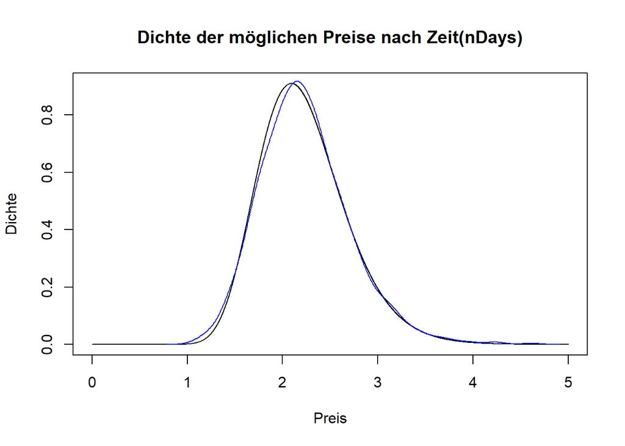

```r
#theoretical density
lnMean = coredata(S0)*exp(vrosMean*nDays)
lnSD = coredata(S0)*exp(vrosMean*nDays)*sqrt(exp((vrosSd^2)*nDays)-1)

meanOfLog = log(S0) + (vrosMean-(vrosSd^2)/2)*nDays
sdOfLog = vrosSd*sqrt(nDays)
priceGrid = seq(0,lnMean+6*lnSD,length=10000)
theoDens = dlnorm(priceGrid,meanOfLog,sdOfLog)
#empirical density
empDens = density(S[nDays,])

#Black line: longnormal distribution of theoretical density
#Blue line: longnormal distribution of empirical density
plot(priceGrid,theoDens,type='l',xlab='Preis',ylab='Dichte',main="Dichte der möglichen Preise nach Zeit(nDays)")
lines(empDens,col='blue')
```

#### Call Put Option price Black Scholes

Resultierende Optionspreise mit dem Modell

```r
S = head(Quandl(vrosDataCode, start_date=startDate, end_date=endDate), n=1)$"Previous Day Price"
strikecall = 1.7
optionCall = GBSOption(TypeFlag = "c", S, strikecall, 1/12, r = 0.03, b = 0.03, vrosSigma)
cat("Option Call Price",optionCall@price)
```

```
## Option Call Price 0.1575292
```

```r
strikeput = 1.4
optionPut = GBSOption(TypeFlag = "p", S, strikeput, 1/12, r = 0.03, b = 0.03, vrosSigma)
cat("Option Put Price",optionPut@price)
```

```
## Option Put Price 1.875406e-08
```

### VALERO ENERGY STOCK

https://www.quandl.com/data/SSE/V1L-VALERO-ENERGY-STOCK-WKN-908683-ISIN-US91913Y1001-V1L-Stuttgart

#### Historische Werte

Tagesabschlüsse von einem Jahr (01.06.2017 - 01.06.2018) werden heruntergeladen und grafisch dargestellt.

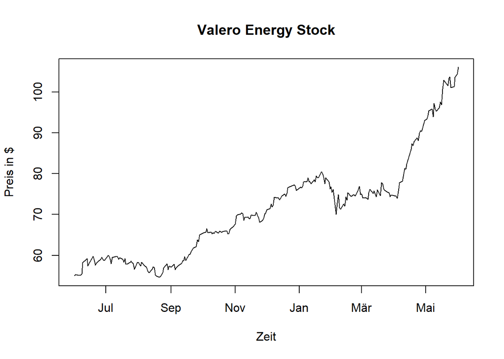

```r
vlDataCode = 'SSE/V1L'
vlLast = Quandl(vlDataCode, type='zoo', collapse="daily", start_date=startDate, end_date=endDate)[,"Last"]

plot(vlLast, ylab="Preis in $",xlab="Zeit",main="Valero Energy Stock")
```

#### Erwartete Tagesrendite [Prozent]

Die prozentuale Tagesrendite ist in der folgenden Graphik zu sehen.

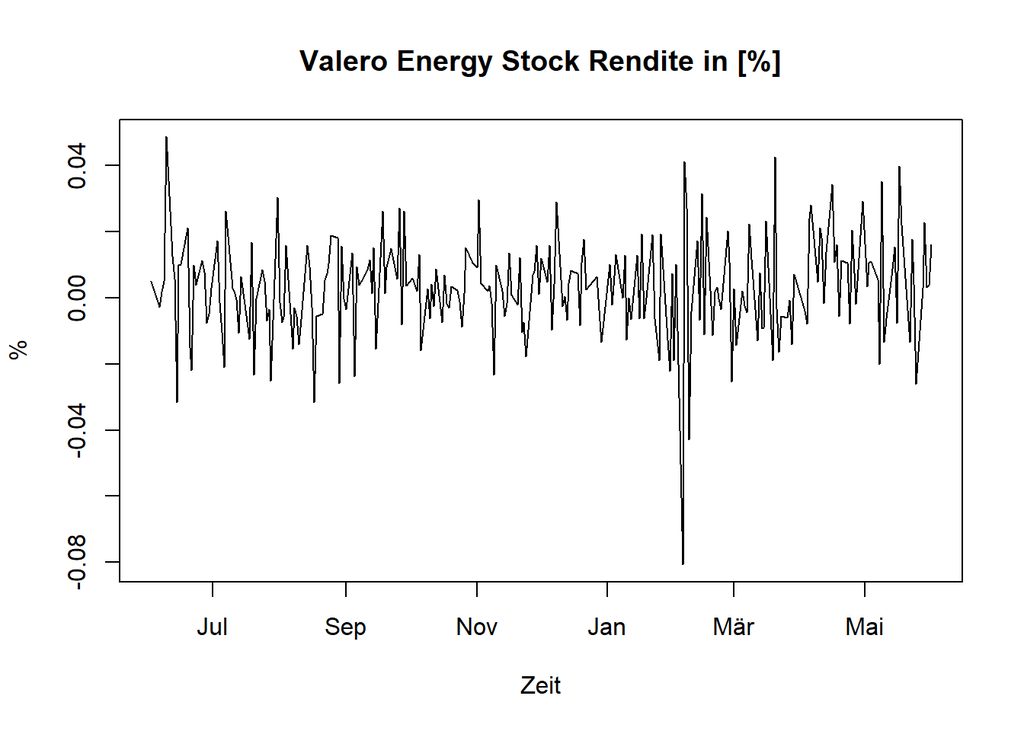

```r
vlReturn = Quandl(vlDataCode, type="zoo",collapse="daily",start_date=startDate, end_date=endDate, transform = "rdiff")[,"Last"]

plot(vlReturn, ylab="%",xlab="Zeit",main="Valero Energy Stock Rendite in [%]")
```

#### Mittelwert und die Standardabweichung

```r
vlSd <- sd(vlReturn)
vlMean <- mean(vlReturn)

vlMatrix = matrix(c(vlSd,vlMean),ncol=2,byrow=TRUE)
colnames(vlMatrix) = c("Standardabweichung","Mittelwert")
print.table(vlMatrix)
```

```
##      Standardabweichung  Mittelwert
## [1,]        0.015115349 0.002742664
```

#### Preisentwicklung mit GBM

Die folgende Graphik zeigt die Simulation mit Geometrischer Brownscher Bewegung. Dargestellt sind 1000 mögliche Preisentwicklungen in dem nächsten halben Jahr.

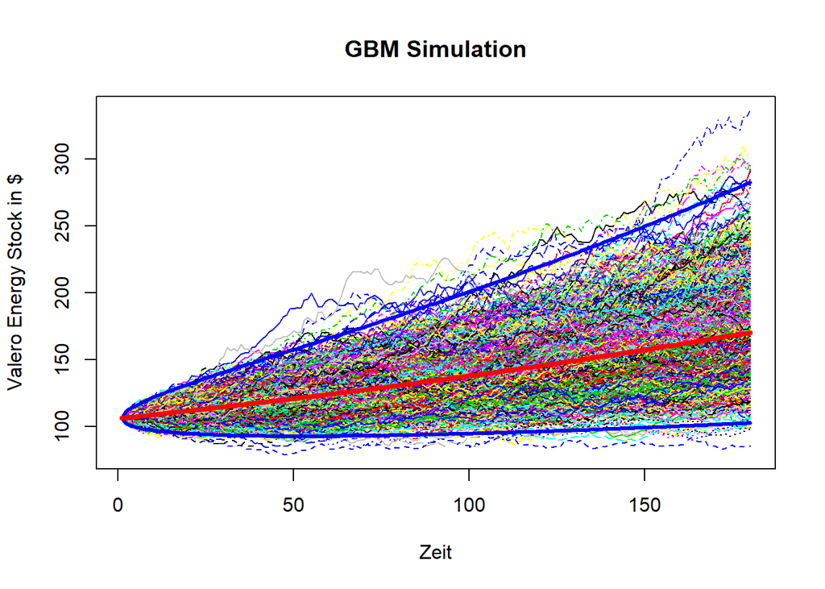

```r
#Simulation
S0 = vlLast[length(vlLast)]
S = matrix(0,nrow=nDays,ncol=nSim)

for (i in 1:nSim) {
  SVec = rep(0, nDays)
  SVec[1] = S0
  for(j in 2:nDays) {
    pastDay = SVec[j-1]
    DeltaS = vlMean*pastDay + vlSd*pastDay*rnorm(1)
    SVec[j] = pastDay+DeltaS
  }
  S[,i] = SVec
}

#Borderlines for the simulation
mean = vlMean * nDays
vlSigma = vlSd * sqrt(nDays)
t = seq(from=0,to=1,length.out=nDays)
meanBnd = vector(length = nDays)
upBnd = vector(length = nDays)
lowBnd = vector(length = nDays)

for(i in 0:nDays){
  meanBnd[i] = S0*exp((( mean-vlSigma^2/2 ))*t[i])
  upBnd[i] = S0*exp((( mean-vlSigma^2/2 ))*t[i] + (vlSigma * 2.5 * sqrt(t[i])))
  lowBnd[i] = S0*exp((( mean-vlSigma^2/2 ))*t[i] + (vlSigma * -2.5 * sqrt(t[i])))
}

#Presentation of the simulation
#Red line: Mean of all simulations
#Blue lines: BOundaris in this simulation
matplot(S,type='l',col=1:100,ylab='Valero Energy Stock in $',xlab='Zeit',main='GBM Simulation')
matlines(lowBnd,lwd=3,col="blue")
matlines(upBnd,lwd=3,col="blue")
matlines(meanBnd,lwd=4,col="red")
```

Die Dichte der Schlusspreise ist in der folgenden Graphik dargestellt.

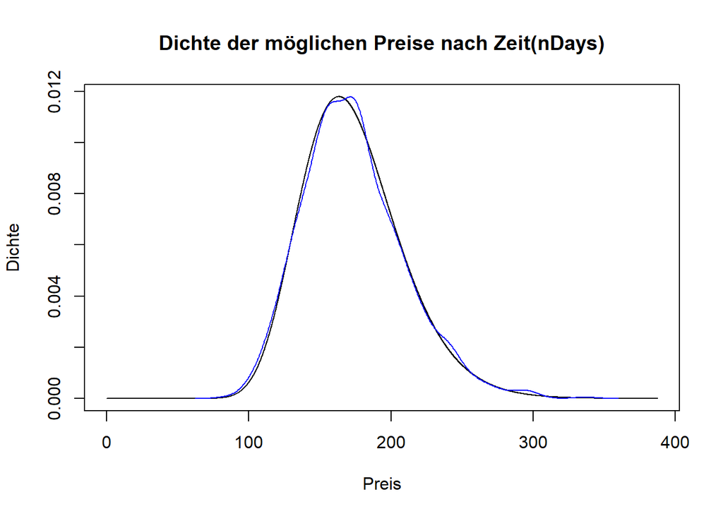

```r
#theoretical density
lnMean = coredata(S0)*exp(vlMean*nDays)
lnSD = coredata(S0)*exp(vlMean*nDays)*sqrt(exp((vlSd^2)*nDays)-1)

meanOfLog = log(S0) + (vlMean-(vlSd^2)/2)*nDays
sdOfLog = vlSd*sqrt(nDays)
priceGrid = seq(0,lnMean+6*lnSD,length=10000)
theoDens = dlnorm(priceGrid,meanOfLog,sdOfLog)
#empirical density
empDens = density(S[nDays,])

#Black line: longnormal distribution of theoretical density
#Blue line: longnormal distribution of empirical density
plot(priceGrid,theoDens,type='l',xlab='Preis',ylab='Dichte' ,main="Dichte der möglichen Preise nach Zeit(nDays)")
lines(empDens,col='blue')
```

#### Call Put Option price Black Scholes

Resultierende Optionspreise mit dem Modell

```r
S = head(Quandl(vlDataCode, start_date=startDate, end_date=endDate), n=1)$"Previous Day Price"
strikecall = 100
optionCall = GBSOption(TypeFlag = "c", S, strikecall, 1/12, r = 0.03, b = 0.03, vlSigma)
cat("Option Call Price",optionCall@price)
```

```
## Option Call Price 5.37978
```

```r
strikeput = 70

optionPut = GBSOption(TypeFlag = "p", S, strikeput, 1/12, r = 0.03, b = 0.03, vlSigma)
cat("Option Put Price",optionPut@price)
```

```
## Option Put Price 2.247317e-12
```